# Data Science Sentimental Text Lab

##Ronica Peraka

```r
library(tidyverse)
```

```r
library(tidytext)
library(ggwordcloud)
library(gutenbergr)
library(textdata)
library(readtext)
```

# Northeast Region of the US

## Article 1: ‘Adapt or Die,’ U.K. Environment Agency Warns on Climate Change

Newspaper: The New York Times

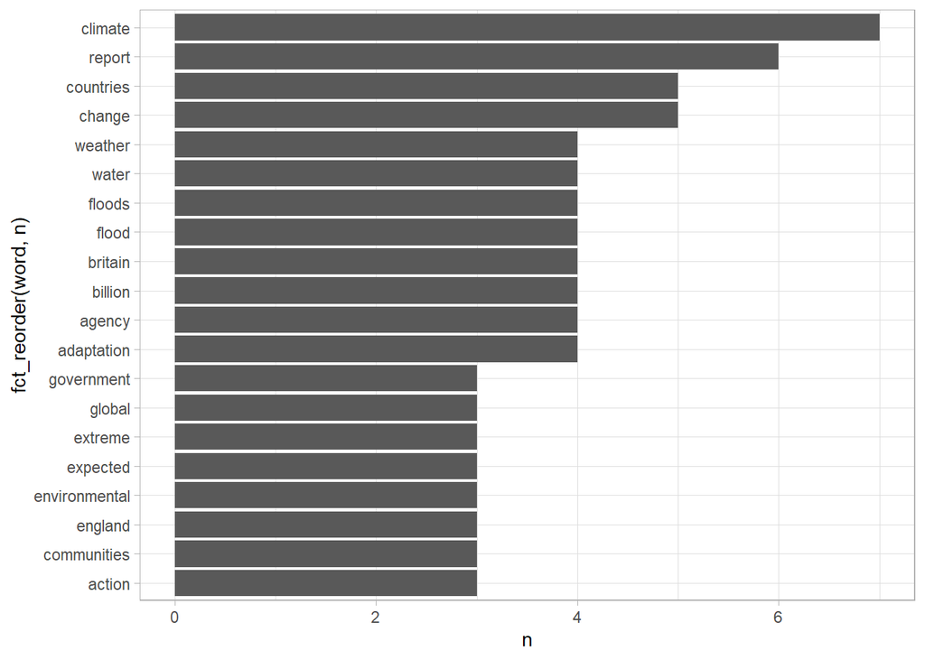

```r
NEarticle1 <- read_lines("07_text_mining/Adapt-or-Die.txt") #this will load and read the file into R
NEarticle1 <- tibble(NEarticle1) #turns the file into a dataframe

NEarticle1$NEarticle1 <- as.character(NEarticle1$NEarticle1)

NEarticle1 <- NEarticle1 %>%
  unnest_tokens(word, NEarticle1)%>%    ##separates each word of 'text' in a variable 'word' using spaces
  anti_join(stop_words)%>%    #removes articles, such as 'the', that don't show additional meaning to the text
  count(word, sort=TRUE)    #portrays how many times each word appears
#View(NEarticle1)

#visual way to see top recurring words
ggplot(
  data = NEarticle1[1:20,],            #I chose to show the top 20 words for readability in graph
  aes(x = fct_reorder(word,n),
      y = n)
  ) +
  geom_col() +
  coord_flip()+
  theme_light()
```

```r
#evaluating words for their connotation
NEarticle1_affin <- NEarticle1 %>%
  inner_join(get_sentiments("afinn")) #using a inner join to match words and add the sentiment variable
NEarticle1_nrc <- NEarticle1 %>%
  inner_join(get_sentiments("nrc"))   #evaluates for tone of words
NEarticle1_bing <- NEarticle1 %>%
  inner_join(get_sentiments("bing"))  #positive and negative
#We can just do some tabling to see the differences in bing and nrc, seems like Kennedy's speech at least first glanced was much more balanced in terms of negative/positive sentiment
table(NEarticle1_bing$sentiment) #much more negative
```

```
##
## negative positive
##       20        9
```

```r
table(NEarticle1_nrc$sentiment)
```

```
##
##        anger anticipation      disgust         fear          joy     negative
##            9           12            7           19            7           20
##     positive      sadness     surprise        trust
##           34            7            6           14
```

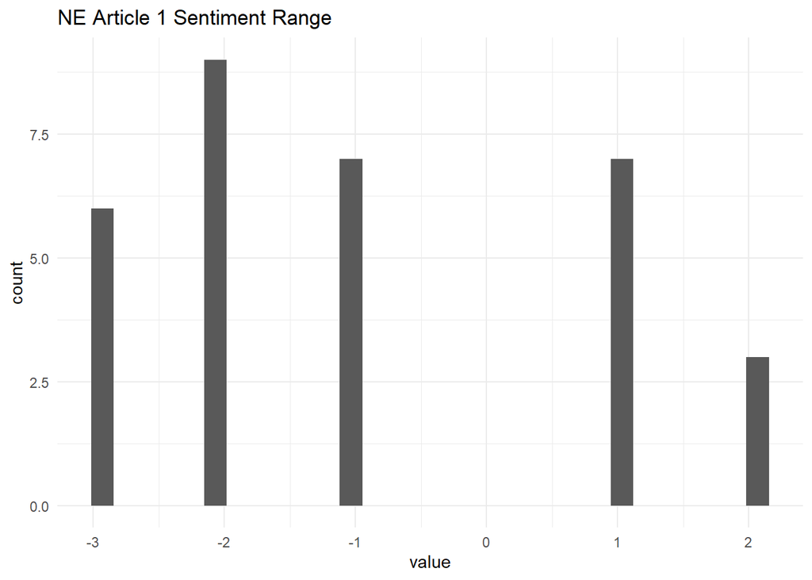

```r
#View(NEarticle1_affin)

#shows the commonality of the values of the words
ggplot(data = NEarticle1_affin,
       aes(x=value)
        )+
  geom_histogram()+
  ggtitle("NE Article 1 Sentiment Range")+
  theme_minimal()
```

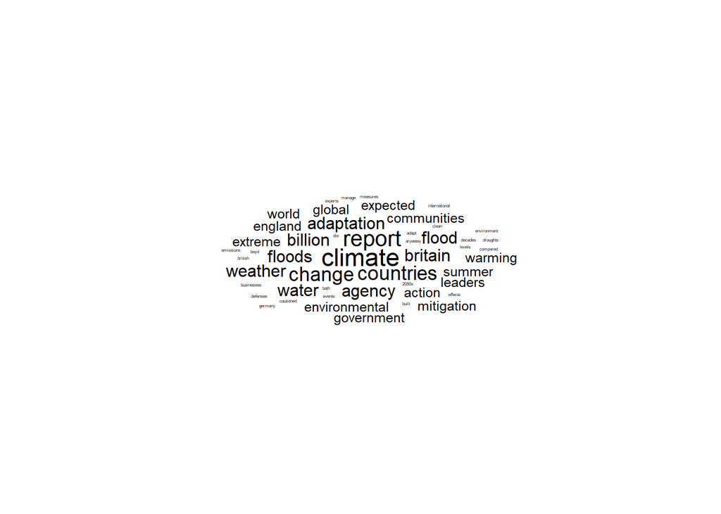

```r
#Could also do simple word clouds as we see
#below uses the ggwordcloud package

set.seed(42)
ggplot(NEarticle1[1:50,], aes(label = word, size = n)
       ) +
  geom_text_wordcloud() +
  theme_minimal()
```

## Article: Yes, Blame Climate Change for the Weather Newspaper: The New York Times

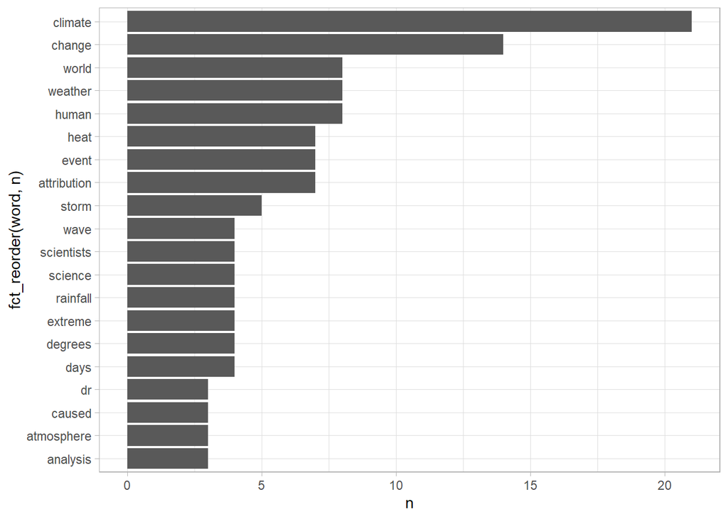

```r
NEarticle2 <- read_lines("07_text_mining/Blame Climate Change for the Weather.txt")

NEarticle2 <- tibble(NEarticle2)
#View(NEarticle2)

NEarticle2$NEarticle2 <- as.character(NEarticle2$NEarticle2)

NEarticle2 <- NEarticle2 %>%
  unnest_tokens(word, NEarticle2)%>%
  anti_join(stop_words)%>%
  count(word, sort=TRUE)
#View(NEarticle2)

ggplot(
  data = NEarticle2[1:20,],
  aes(x = fct_reorder(word,n),
      y = n)
  ) +
  geom_col() +
  coord_flip()+
  theme_light()
```

```r
#evaluating words for their connotation
NEarticle2_affin <- NEarticle2 %>%
  inner_join(get_sentiments("afinn"))#using a inner join to match words and add the sentiment variable
NEarticle2_nrc <- NEarticle2 %>%
  inner_join(get_sentiments("nrc"))
NEarticle2_bing <- NEarticle2 %>%
  inner_join(get_sentiments("bing"))
#We can just do some tabling to see the differences in bing and nrc, seems like Kennedy's speech at least first glanced was much more balanced in terms of negative/positive sentiment
table(NEarticle2_bing$sentiment) #much more positive
```

```
##
## negative positive
##       23       13
```

```r
table(NEarticle2_nrc$sentiment)
```

```
##
##        anger anticipation      disgust         fear          joy     negative
##           16            8            8           16            5           22
##     positive      sadness     surprise        trust
##           23           14           10           12
```

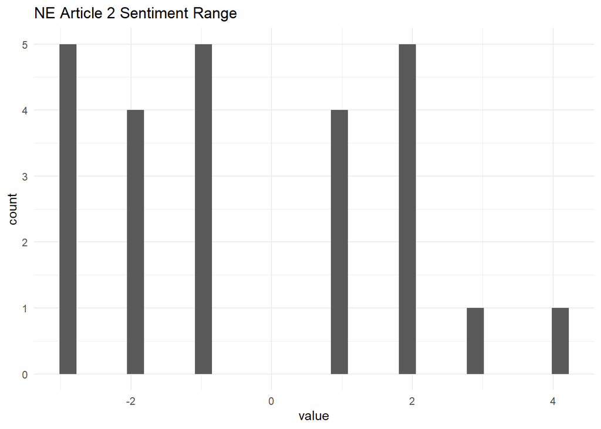

```r
#View(NEarticle2_affin)

ggplot(data = NEarticle2_affin,
       aes(x=value)
        )+
  geom_histogram()+
  ggtitle("NE Article 2 Sentiment Range")+
  theme_minimal()
```

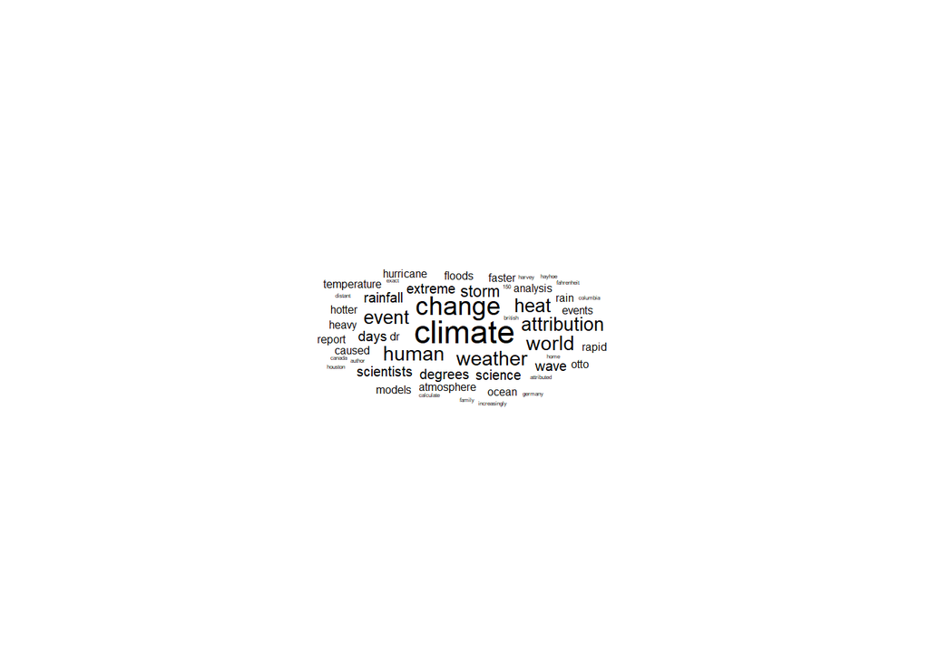

```r
#Could also do simple word clouds as we see
#below uses the ggwordcloud package

set.seed(42)
ggplot(NEarticle2[1:50,], aes(label = word, size = n)
       ) +
  geom_text_wordcloud() +
  theme_minimal()
```

## Article: Climate Change Is Destroying My Country. The Nations Causing It Must Help.; The Climate Issue Newspaper: The New York Times

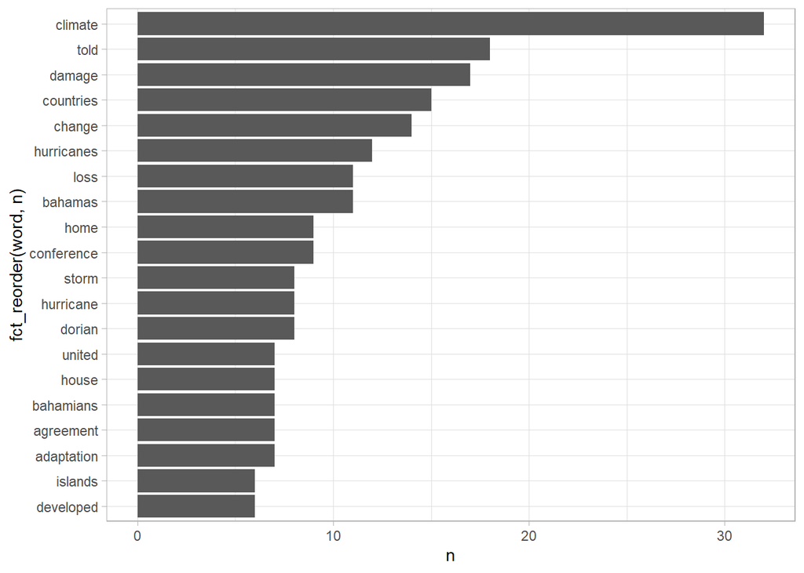

```r
NEarticle3 <- read_lines("07_text_mining/Destroying-My-Country.txt")

NEarticle3 <- tibble(NEarticle3)
#View(NEarticle3)

NEarticle3$NEarticle3 <- as.character(NEarticle3$NEarticle3)

NEarticle3 <- NEarticle3 %>%
  unnest_tokens(word, NEarticle3)%>%
  anti_join(stop_words)%>%
  count(word, sort=TRUE)
#View(NEarticle3)

ggplot(
  data = NEarticle3[1:20,],
  aes(x = fct_reorder(word,n),
      y = n)
  ) +
  geom_col() +
  coord_flip()+
  theme_light()
```

```r
#evaluating words for their connotation
NEarticle3_affin <- NEarticle3 %>%
  inner_join(get_sentiments("afinn"))#using a inner join to match words and add the sentiment variable
NEarticle3_nrc <- NEarticle3 %>%
  inner_join(get_sentiments("nrc"))
NEarticle3_bing <- NEarticle3 %>%
  inner_join(get_sentiments("bing"))
#We can just do some tabling to see the differences in bing and nrc, seems like Kennedy's speech at least first glanced was much more balanced in terms of negative/positive sentiment
table(NEarticle3_bing$sentiment) #much more positive
```

```
##
## negative positive
##       73       54
```

```r
table(NEarticle3_nrc$sentiment)
```

```
##
##        anger anticipation      disgust         fear          joy     negative
##           31           43           22           46           35           64
##     positive      sadness     surprise        trust
##          112           33           19           64
```

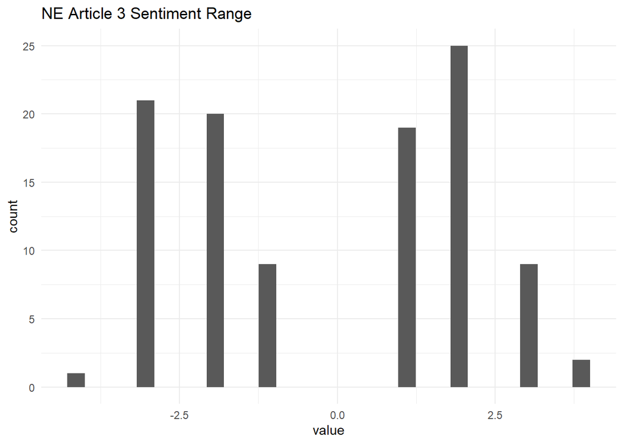

```r
#View(NEarticle3_affin)

ggplot(data = NEarticle3_affin,
       aes(x=value)
        )+
  geom_histogram()+
  ggtitle("NE Article 3 Sentiment Range")+
  theme_minimal()
```

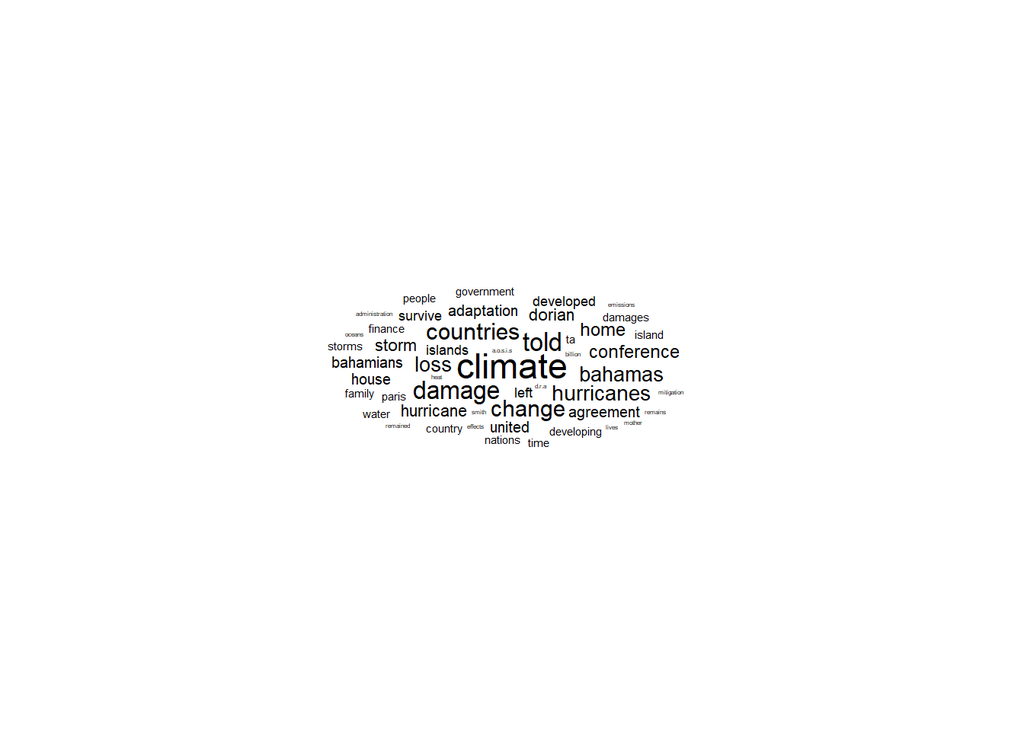

```r
#Could also do simple word clouds as we see
#below uses the ggwordcloud package

set.seed(42)
ggplot(NEarticle3[1:50,], aes(label = word, size = n)
       ) +
  geom_text_wordcloud() +
  theme_minimal()
```

## Article: Climate change: England must ‘adapt or die,’ agency warns

Newspaper: The Associated Press

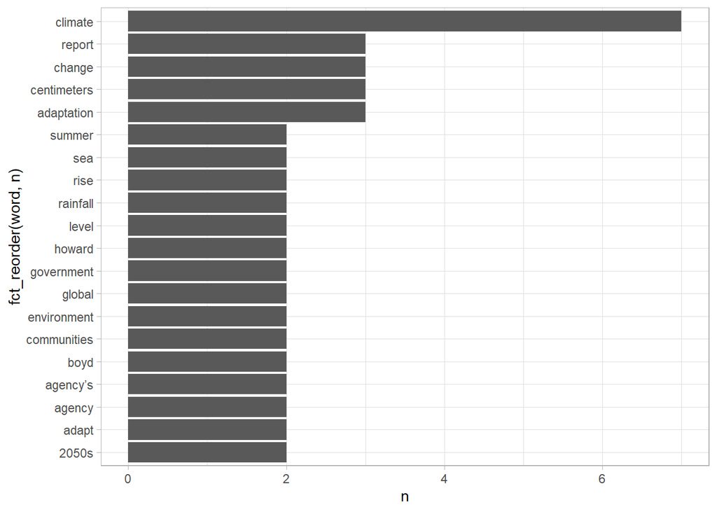

```r
NEarticle4 <- read_lines("07_text_mining/England must.txt")

NEarticle4 <- tibble(NEarticle4)
#View(NEarticle4)

NEarticle4$NEarticle4 <- as.character(NEarticle4$NEarticle4)

NEarticle4 <- NEarticle4 %>%
  unnest_tokens(word, NEarticle4)%>%
  anti_join(stop_words)%>%
  count(word, sort=TRUE)
#View(NEarticle4)

ggplot(
  data = NEarticle4[1:20,],
  aes(x = fct_reorder(word,n),
      y = n)
  ) +
  geom_col() +
  coord_flip()+
  theme_light()
```

```r
#evaluating words for their connotation
NEarticle4_affin <- NEarticle4 %>%
  inner_join(get_sentiments("afinn"))#using a inner join to match words and add the sentiment variable
NEarticle4_nrc <- NEarticle4 %>%
  inner_join(get_sentiments("nrc"))
NEarticle4_bing <- NEarticle4 %>%
  inner_join(get_sentiments("bing"))
#We can just do some tabling to see the differences in bing and nrc, seems like Kennedy's speech at least first glanced was much more balanced in terms of negative/positive sentiment
table(NEarticle4_bing$sentiment) #much more positive
```

```
##
## negative positive
##       11        7
```

```r
table(NEarticle4_nrc$sentiment)
```

```
##
##        anger anticipation      disgust         fear          joy     negative
##            5            7            1            8            2            9
##     positive      sadness     surprise        trust
##           12            5            3            3
```

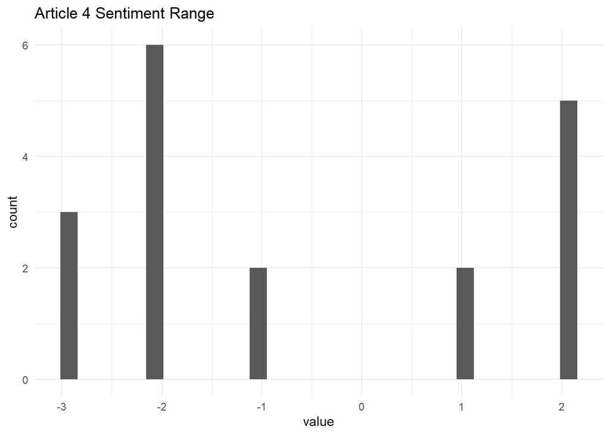

```r
#View(NEarticle4_affin)

ggplot(data = NEarticle4_affin,
       aes(x=value)
        )+
  geom_histogram()+
  ggtitle("Article 4 Sentiment Range")+
  theme_minimal()
```

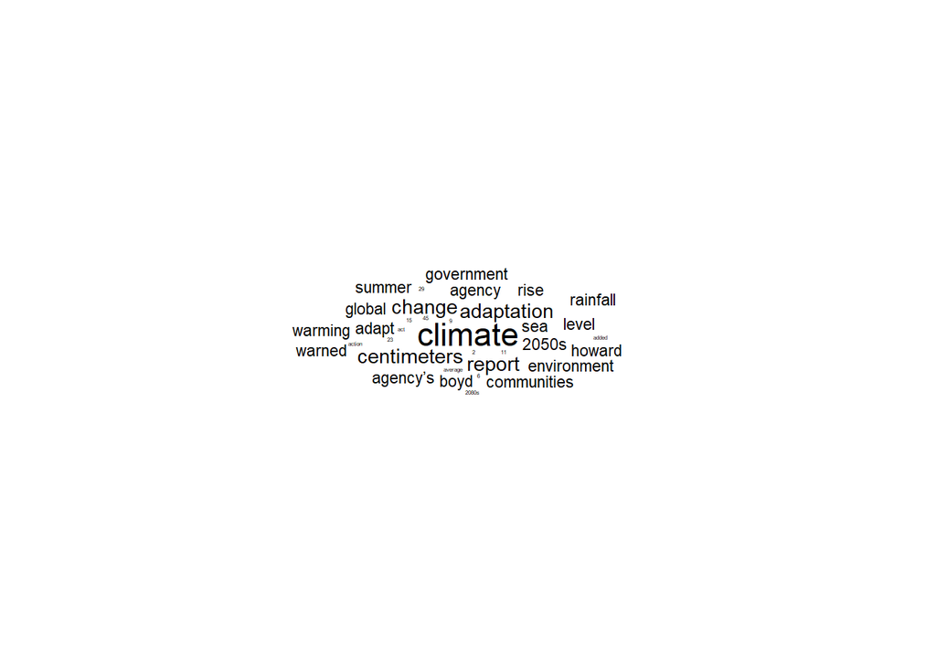

```r
#Could also do simple word clouds as we see
#below uses the ggwordcloud package

set.seed(42)
ggplot(NEarticle4[1:35,], aes(label = word, size = n)
       ) +
  geom_text_wordcloud() +
  theme_minimal()
```

## Article: Fossil-Fuel Use May Peak Soon, but Perils of Climate Change Still Loom

Newspaper: The New York Times

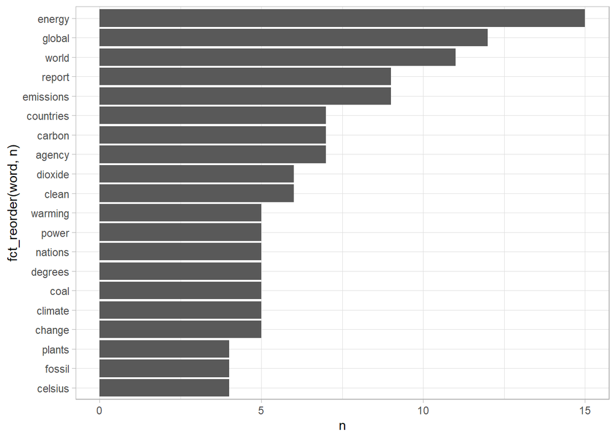

```r
NEarticle5 <- read_lines("07_text_mining/Fossil-Fuel-Peak.txt")

NEarticle5 <- tibble(NEarticle5)
#View(NEarticle5)

NEarticle5$NEarticle5 <- as.character(NEarticle5$NEarticle5)

NEarticle5 <- NEarticle5 %>%
  unnest_tokens(word, NEarticle5)%>%
  anti_join(stop_words)%>%
  count(word, sort=TRUE)
#View(NEarticle5)

ggplot(
  data = NEarticle5[1:20,],
  aes(x = fct_reorder(word,n),
      y = n)
  ) +
  geom_col() +
  coord_flip()+
  theme_light()
```

```r
#evaluating words for their connotation
NEarticle5_affin <- NEarticle5 %>%
  inner_join(get_sentiments("afinn"))#using a inner join to match words and add the sentiment variable
NEarticle5_nrc <- NEarticle5 %>%
  inner_join(get_sentiments("nrc"))
NEarticle5_bing <- NEarticle5 %>%
  inner_join(get_sentiments("bing"))
#We can just do some tabling to see the differences in bing and nrc, seems like Kennedy's speech at least first glanced was much more balanced in terms of negative/positive sentiment
table(NEarticle5_bing$sentiment) #much more positive
```

```
##
## negative positive
##       27       15
```

```r
table(NEarticle5_nrc$sentiment)
```

```
##
##        anger anticipation      disgust         fear          joy     negative
##            7           12            5           15            9           21
##     positive      sadness     surprise        trust
##           29           10            7           13
```

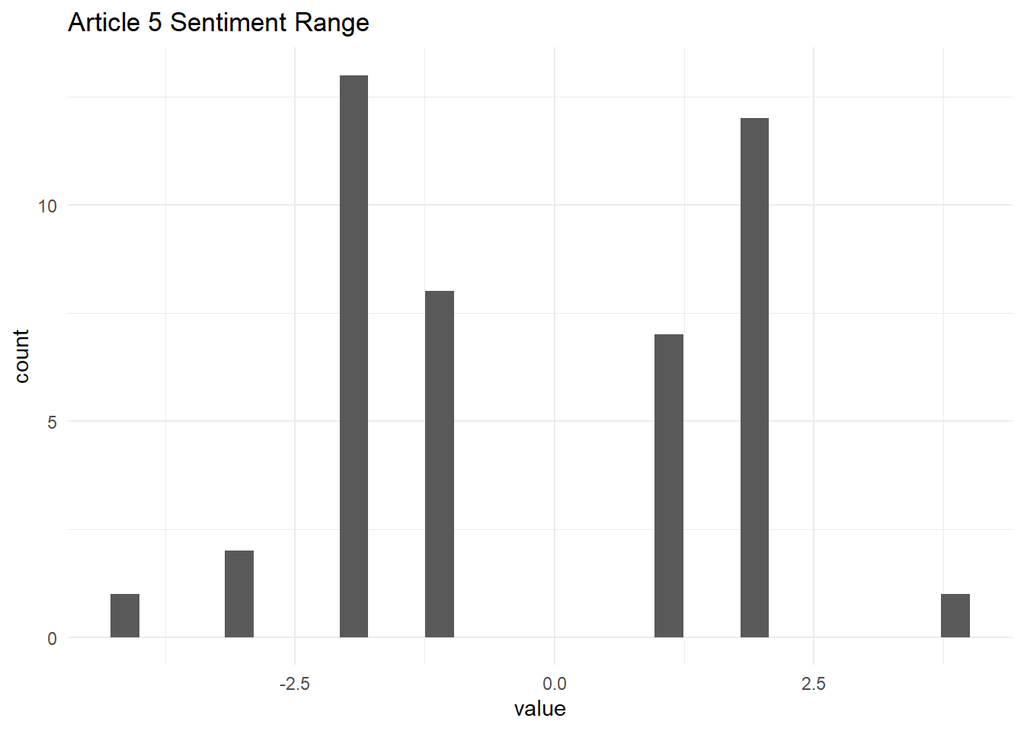

```r
#View(NEarticle5_affin)

ggplot(data = NEarticle5_affin,
       aes(x=value)
        )+
  geom_histogram()+
  ggtitle("Article 5 Sentiment Range")+
  theme_minimal()
```

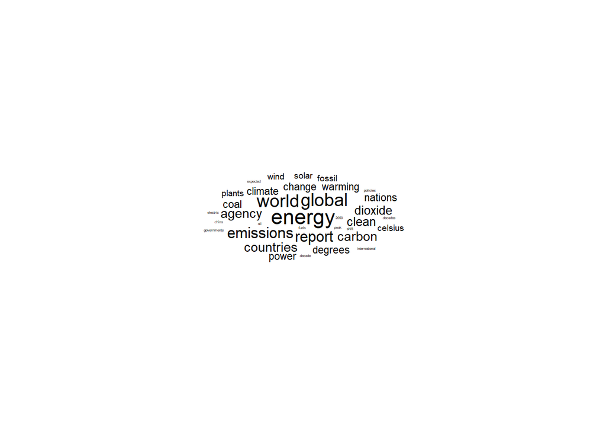

```r
#Could also do simple word clouds as we see
#below uses the ggwordcloud package

set.seed(42)
ggplot(NEarticle5[1:35,], aes(label = word, size = n)
       ) +
  geom_text_wordcloud() +
  theme_minimal()
```

## Article: Google bans ads on content, including YouTube videos, with false claims about climate change.

Newspaper: The New York Times

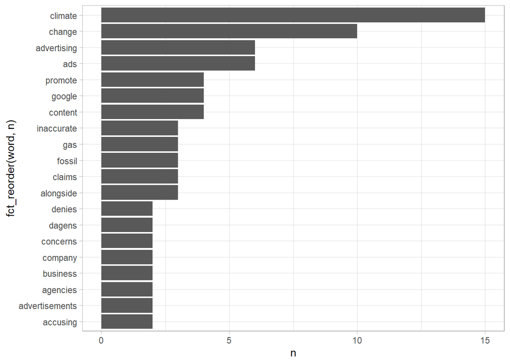

```r
NEarticle6 <- read_lines("07_text_mining/Google bans ads.txt")

NEarticle6 <- tibble(NEarticle6)
#View(NEarticle6)

NEarticle6$NEarticle6 <- as.character(NEarticle6$NEarticle6)

NEarticle6 <- NEarticle6 %>%
  unnest_tokens(word, NEarticle6)%>%
  anti_join(stop_words)%>%
  count(word, sort=TRUE)
#View(NEarticle6)

ggplot(
  data = NEarticle6[1:20,],
  aes(x = fct_reorder(word,n),
      y = n)
  ) +
  geom_col() +
  coord_flip()+
  theme_light()
```

```r
#evaluating words for their connotation
NEarticle6_affin <- NEarticle6 %>%
  inner_join(get_sentiments("afinn"))#using a inner join to match words and add the sentiment variable
NEarticle6_nrc <- NEarticle6 %>%
  inner_join(get_sentiments("nrc"))
NEarticle6_bing <- NEarticle6 %>%
  inner_join(get_sentiments("bing"))
#We can just do some tabling to see the differences in bing and nrc, seems like Kennedy's speech at least first glanced was much more balanced in terms of negative/positive sentiment
table(NEarticle6_bing$sentiment) #much more positive
```

```
##
## negative positive
##       15        3
```

```r
table(NEarticle6_nrc$sentiment)
```

```
##
##        anger anticipation      disgust         fear          joy     negative
##            7            8            2            4            4           13
##     positive      sadness     surprise        trust
##           12            3            2           14
```

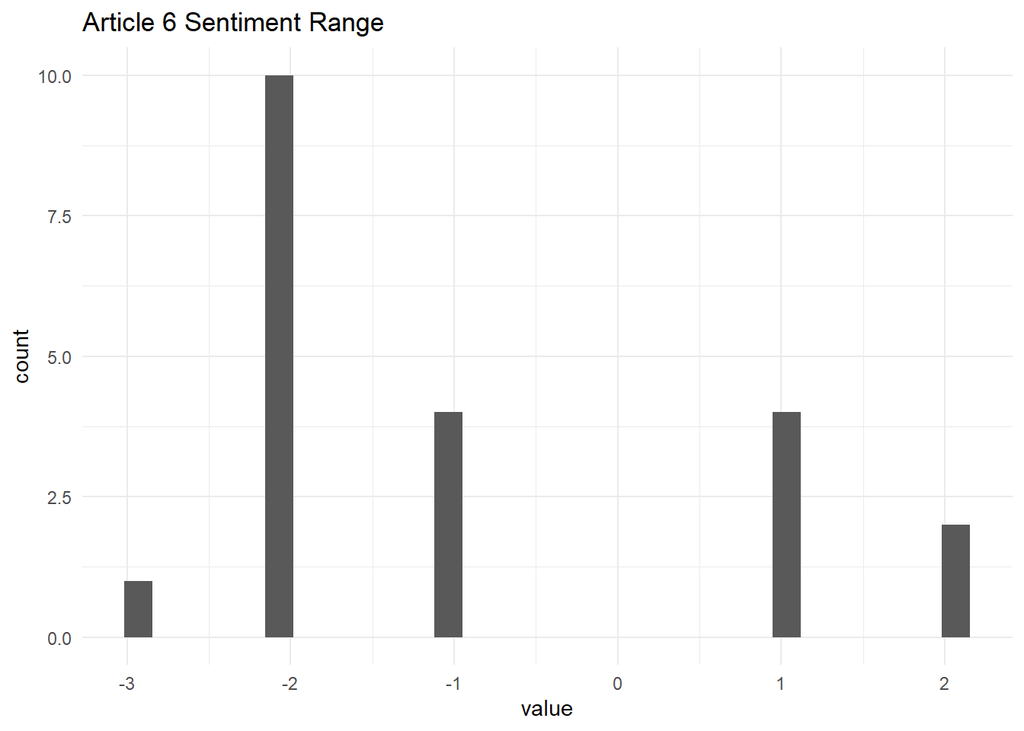

```r
#View(NEarticle6_affin)

ggplot(data = NEarticle6_affin,
       aes(x=value)
        )+
  geom_histogram()+
  ggtitle("Article 6 Sentiment Range")+
  theme_minimal()
```

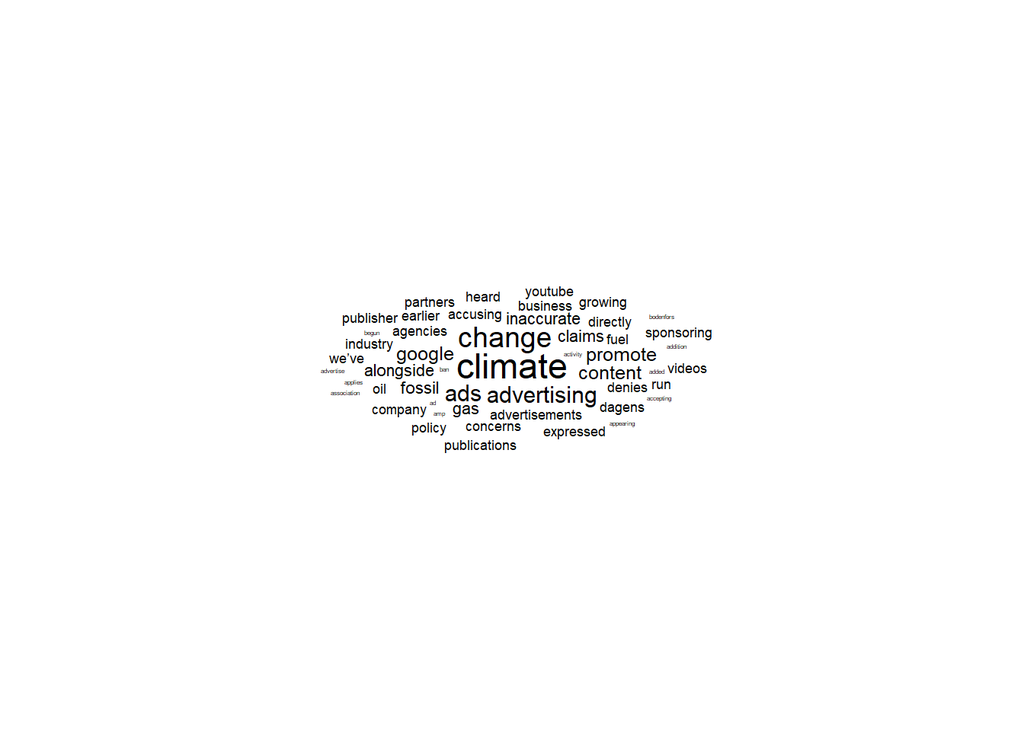

```r
#Could also do simple word clouds as we see
#below uses the ggwordcloud package

set.seed(42)
ggplot(NEarticle6[1:50,], aes(label = word, size = n)
       ) +
  geom_text_wordcloud() +
  theme_minimal()
```

## Article: How the Animal World Is Adapting to Climate Change; Nonfiction

Newspaper: The New York Times

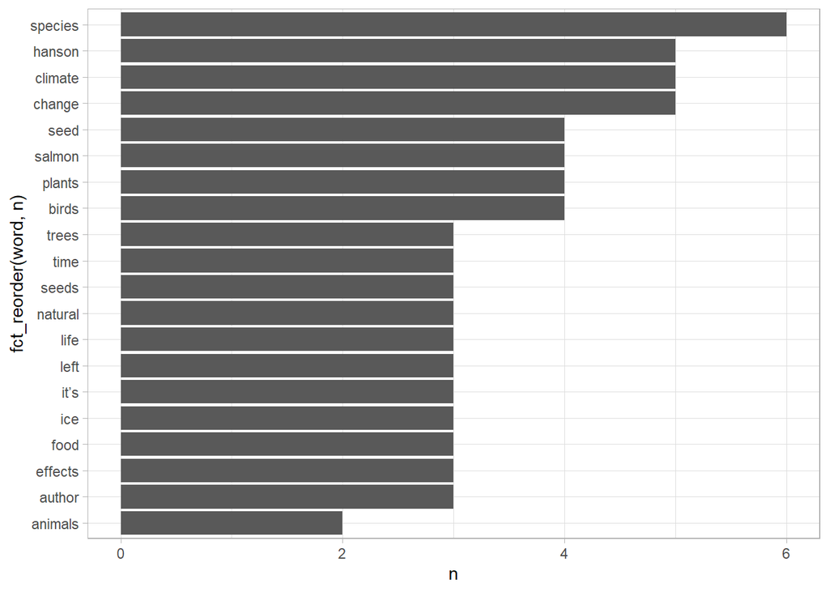

```r
NEarticle7 <- read_lines("07_text_mining/How the Animal World Is Adapting to Climate Change_ Non.txt")

NEarticle7 <- tibble(NEarticle7)
#View(NEarticle7)

NEarticle7$NEarticle7 <- as.character(NEarticle7$NEarticle7)

NEarticle7 <- NEarticle7 %>%
  unnest_tokens(word, NEarticle7)%>%
  anti_join(stop_words)%>%
  count(word, sort=TRUE)
#View(NEarticle7)

ggplot(
  data = NEarticle7[1:20,],
  aes(x = fct_reorder(word,n),
      y = n)
  ) +
  geom_col() +
  coord_flip()+
  theme_light()
```

```r
#evaluating words for their connotation
NEarticle7_affin <- NEarticle7 %>%
  inner_join(get_sentiments("afinn"))#using a inner join to match words and add the sentiment variable
NEarticle7_nrc <- NEarticle7 %>%
  inner_join(get_sentiments("nrc"))
NEarticle7_bing <- NEarticle7 %>%
  inner_join(get_sentiments("bing"))
#We can just do some tabling to see the differences in bing and nrc, seems like Kennedy's speech at least first glanced was much more balanced in terms of negative/positive sentiment
table(NEarticle7_bing$sentiment) #much more positive
```

```
##
## negative positive
##       40       36
```

```r
table(NEarticle7_nrc$sentiment)
```

```
##
##        anger anticipation      disgust         fear          joy     negative
##           16           28           13           25           17           46
##     positive      sadness     surprise        trust
##           52           20           14           26
```

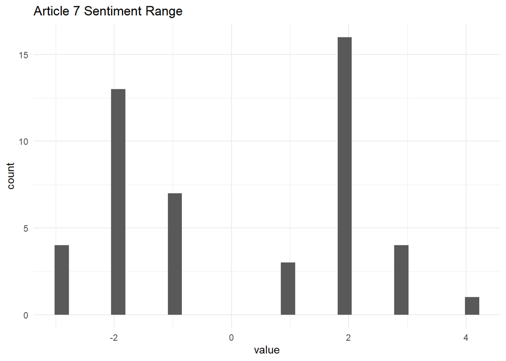

```r
#View(NEarticle7_affin)

ggplot(data = NEarticle7_affin,
       aes(x=value)
        )+
  geom_histogram()+
  ggtitle("Article 7 Sentiment Range")+
  theme_minimal()
```

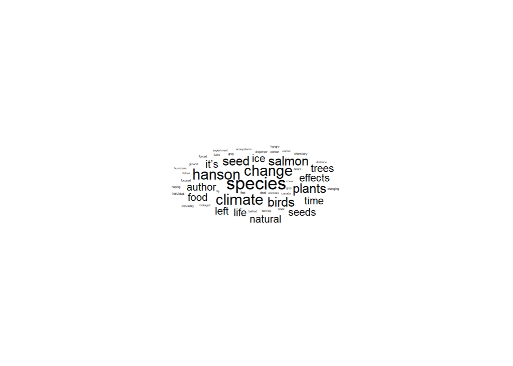

```r
#Could also do simple word clouds as we see
#below uses the ggwordcloud package

set.seed(42)
ggplot(NEarticle7[1:50,], aes(label = word, size = n)
       ) +
  geom_text_wordcloud() +
  theme_minimal()
```

## Article: Looking out for number 2; Farmer has a manure solution for fighting climate change

Newspaper: The Philadelphia Daily News

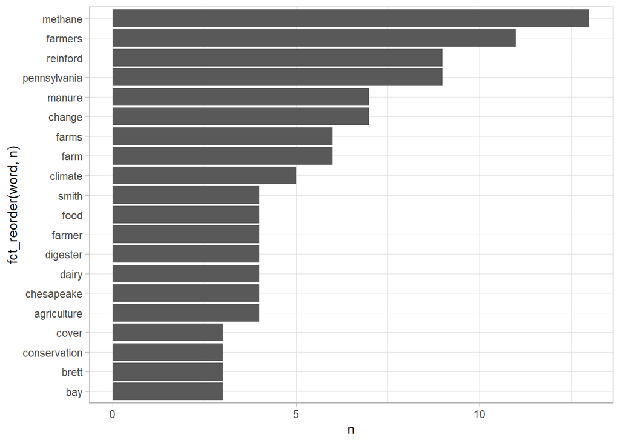

```r
NEarticle8 <- read_lines("07_text_mining/Looking out for number 2_ Farmer has a manure solution.txt")

NEarticle8 <- tibble(NEarticle8)
#View(NEarticle8)

NEarticle8$NEarticle8 <- as.character(NEarticle8$NEarticle8)

NEarticle8 <- NEarticle8 %>%
  unnest_tokens(word, NEarticle8)%>%
  anti_join(stop_words)%>%
  count(word, sort=TRUE)
#View(NEarticle8)

ggplot(
  data = NEarticle8[1:20,],
  aes(x = fct_reorder(word,n),
      y = n)
  ) +
  geom_col() +
  coord_flip()+
  theme_light()
```

```r
#evaluating words for their connotation
NEarticle8_affin <- NEarticle8 %>%
  inner_join(get_sentiments("afinn"))#using a inner join to match words and add the sentiment variable
NEarticle8_nrc <- NEarticle8 %>%
  inner_join(get_sentiments("nrc"))
NEarticle8_bing <- NEarticle8 %>%
  inner_join(get_sentiments("bing"))
#We can just do some tabling to see the differences in bing and nrc, seems like Kennedy's speech at least first glanced was much more balanced in terms of negative/positive sentiment
table(NEarticle8_bing$sentiment) #much more positive
```

```
##
## negative positive
##        9       11
```

```r
table(NEarticle8_nrc$sentiment)
```

```
##
##        anger anticipation      disgust         fear          joy     negative
##            8           18            6            4           12           17
##     positive      sadness     surprise        trust
##           41            3            4           26
```

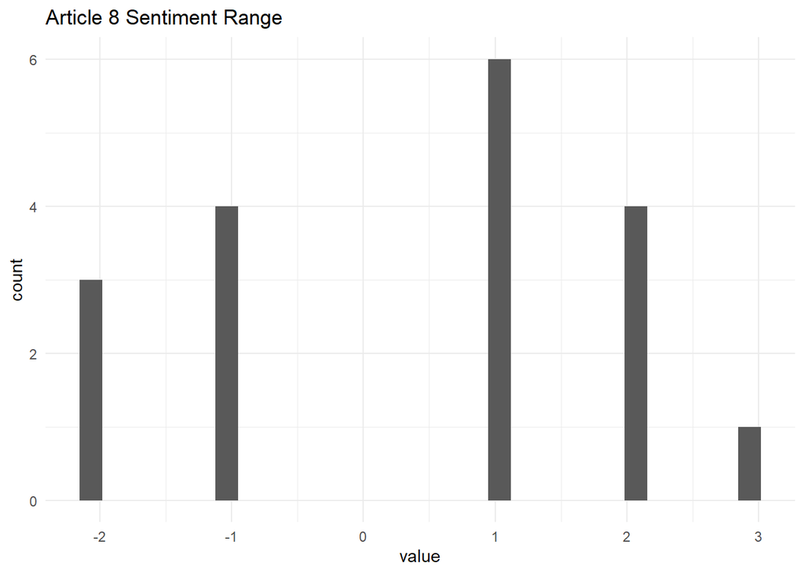

```r
#View(NEarticle8_affin)

ggplot(data = NEarticle8_affin,
       aes(x=value)
        )+
  geom_histogram()+
  ggtitle("Article 8 Sentiment Range")+
  theme_minimal()
```

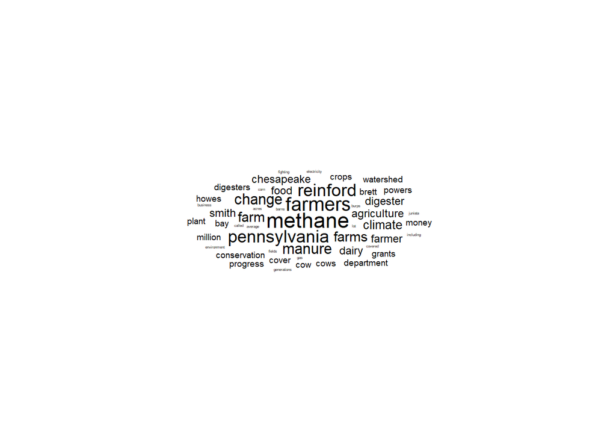

```r
#Could also do simple word clouds as we see
#below uses the ggwordcloud package

set.seed(42)
ggplot(NEarticle8[1:50,], aes(label = word, size = n)
       ) +
  geom_text_wordcloud() +
  theme_minimal()
```

## Article: Potsdam town and village recognized for climate change efforts

Newspaper: The New York Times

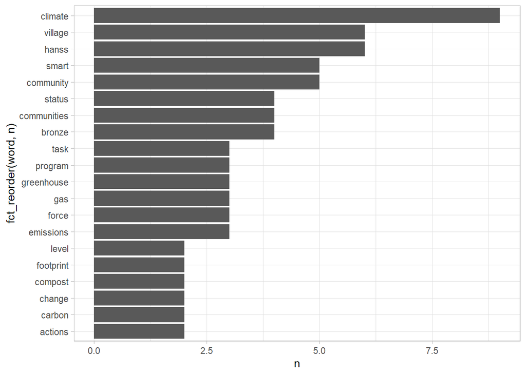

```r
NEarticle9 <- read_lines("07_text_mining/Potsdam town and village recognized for climate change.txt")

NEarticle9 <- tibble(NEarticle9)
#View(NEarticle9)

NEarticle9$NEarticle9 <- as.character(NEarticle9$NEarticle9)

NEarticle9 <- NEarticle9 %>%
  unnest_tokens(word, NEarticle9)%>%
  anti_join(stop_words)%>%
  count(word, sort=TRUE)
#View(NEarticle9)

ggplot(
  data = NEarticle9[1:20,],
  aes(x = fct_reorder(word,n),
      y = n)
  ) +
  geom_col() +
  coord_flip()+
  theme_light()
```

```r
#evaluating words for their connotation
NEarticle9_affin <- NEarticle9 %>%
  inner_join(get_sentiments("afinn"))#using a inner join to match words and add the sentiment variable
NEarticle9_nrc <- NEarticle9 %>%
  inner_join(get_sentiments("nrc"))
NEarticle9_bing <- NEarticle9 %>%
  inner_join(get_sentiments("bing"))
#We can just do some tabling to see the differences in bing and nrc, seems like Kennedy's speech at least first glanced was much more balanced in terms of negative/positive sentiment
table(NEarticle9_bing$sentiment) #much more positive
```

```
##
## negative positive
##        2        6
```

```r
table(NEarticle9_nrc$sentiment)
```

```
##
##        anger anticipation      disgust         fear          joy     negative
##            1            7            2            2            4            4
##     positive      sadness     surprise        trust
##           19            1            2           10
```

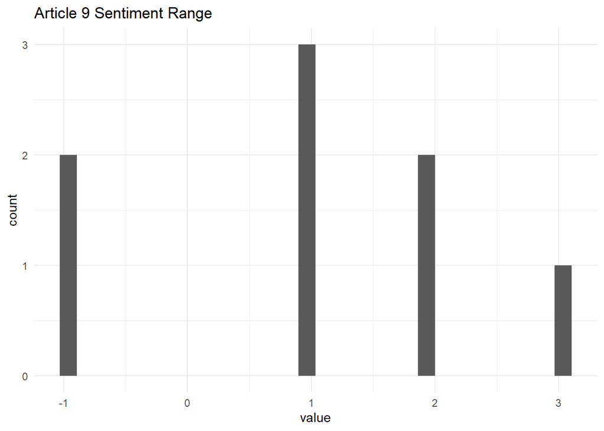

```r
#View(NEarticle9_affin)

ggplot(data = NEarticle9_affin,
       aes(x=value)
        )+
  geom_histogram()+
  ggtitle("Article 9 Sentiment Range")+
  theme_minimal()
```

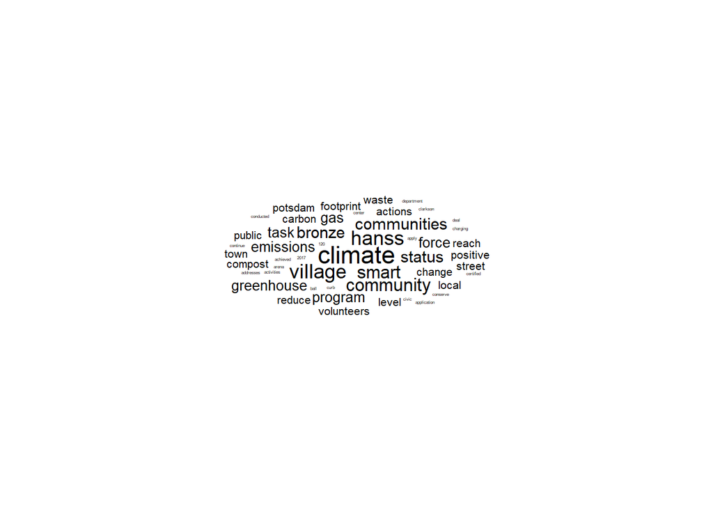

```r
#Could also do simple word clouds as we see
#below uses the ggwordcloud package

set.seed(42)
ggplot(NEarticle9[1:50,], aes(label = word, size = n)
       ) +
  geom_text_wordcloud() +
  theme_minimal()
```

## Article: Share the Cost of Climate Change

Newspaper: The New York Times

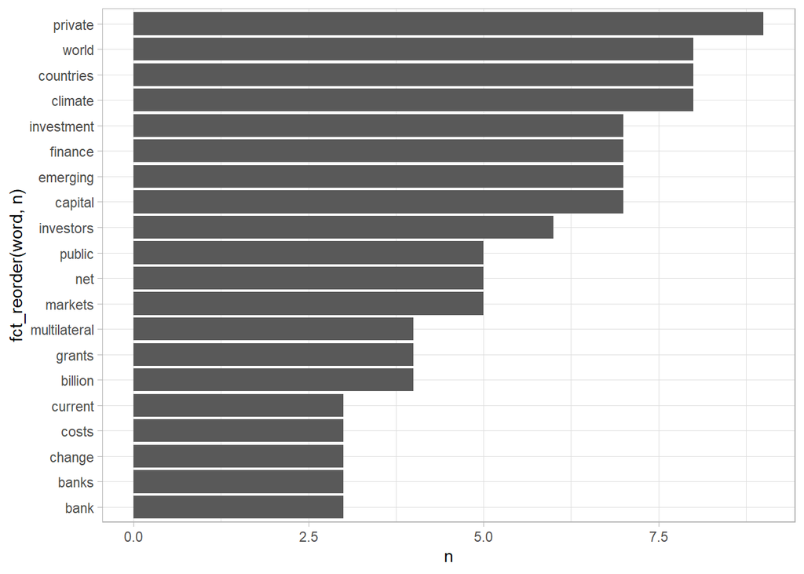

```r
NEarticle10 <- read_lines("07_text_mining/Share-the-Cost-of-Climate-Change.txt")

NEarticle10 <- tibble(NEarticle10)
#View(NEarticle10)

NEarticle10$NEarticle10 <- as.character(NEarticle10$NEarticle10)

NEarticle10 <- NEarticle10 %>%
  unnest_tokens(word, NEarticle10)%>%
  anti_join(stop_words)%>%
  count(word, sort=TRUE)
#View(NEarticle10)

ggplot(
  data = NEarticle10[1:20,],
  aes(x = fct_reorder(word,n),
      y = n)
  ) +
  geom_col() +
  coord_flip()+
  theme_light()
```

```r
#evaluating words for their connotation
NEarticle10_affin <- NEarticle10 %>%
  inner_join(get_sentiments("afinn"))#using a inner join to match words and add the sentiment variable
NEarticle10_nrc <- NEarticle10 %>%
  inner_join(get_sentiments("nrc"))
NEarticle10_bing <- NEarticle10 %>%
  inner_join(get_sentiments("bing"))
#We can just do some tabling to see the differences in bing and nrc, seems like Kennedy's speech at least first glanced was much more balanced in terms of negative/positive sentiment
table(NEarticle10_bing$sentiment) #much more positive
```

```
##
## negative positive
##       19       13
```

```r
table(NEarticle10_nrc$sentiment)
```

```
##
##        anger anticipation      disgust         fear          joy     negative
##            7           11            5           12            6           12
##     positive      sadness     surprise        trust
##           27            7            6           13
```

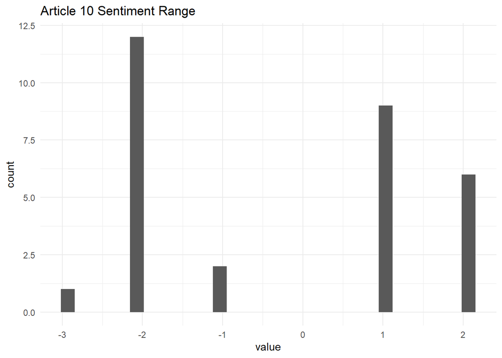

```r
#View(NEarticle10_affin)

ggplot(data = NEarticle10_affin,
       aes(x=value)
        )+
  geom_histogram()+
  ggtitle("Article 10 Sentiment Range")+
  theme_minimal()
```

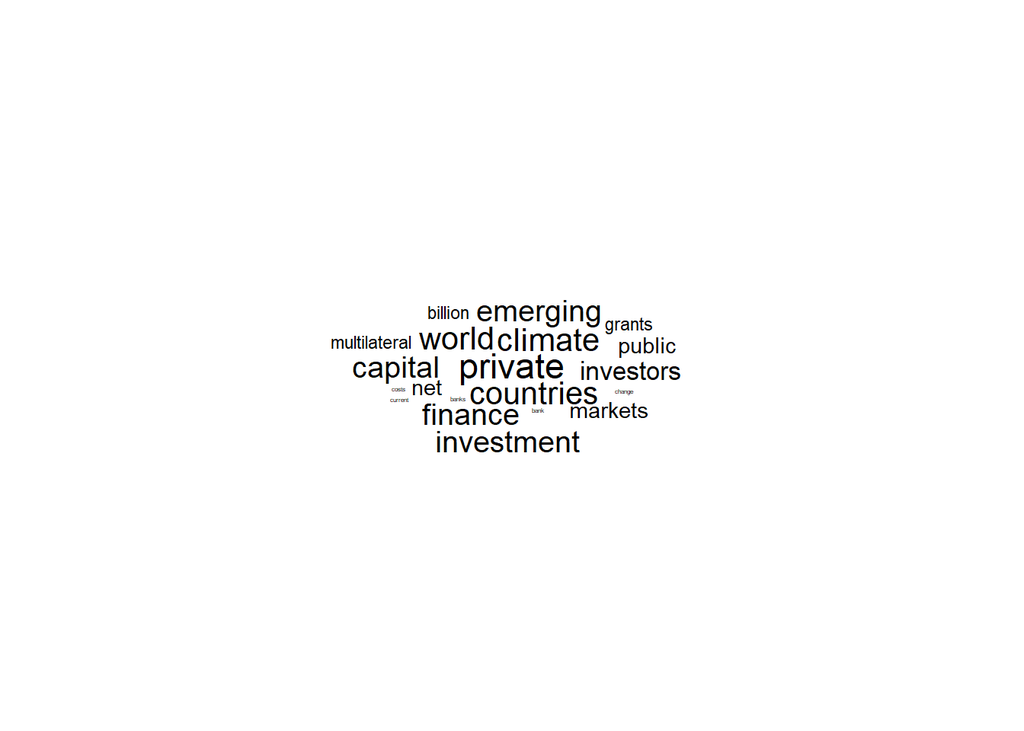

```r
#Could also do simple word clouds as we see
#below uses the ggwordcloud package

set.seed(42)
ggplot(NEarticle10[1:20,], aes(label = word, size = n)
       ) +
  geom_text_wordcloud() +
  theme_minimal()
```